# RuralSTAMINA Biomanufacturing Engine: knowledge base

NSF Regional Innovation Engines, Cohort 2. Technology profile v3.1. Draft, in progress

**NSF RuralSTAMINA Biomanufacturing Engine in Iowa and Nebraska**, led by Iowa State University. NSF award 2532118, start August 2026. Search window for papers and patents: from August 2021 (five years before the award) onward.

## At a glance

| Measure | Value |
| --- | --- |
| People named by NSF or the Engine’s site | 9 |
| of them active researchers (>= 5 works since window start) | 2 |
| Team members who are inventors (2021-2025 grants, in the region) | 2 |
| Partners (site list + team members’ organisations) | 8 |
| Knowledge-producer partners (universities, labs, institutes) | 3 |
| Partner papers in the Engine’s topics | 215 |
| of them with an in-region partner | 215 |
| Regional patents in the technology profile (2021-2025 grants) | 580 |
| Location quotient of the technology profile (patents) | 2.84 |
| Share of regional technology patents owned by partners | 8.6% |

## Economic base

| NAICS | Industry | Employment in region | Establishments | Share of US employment | Employment LQ |
| --- | --- | --- | --- | --- | --- |
| 3251 | Basic chemical manufacturing (incl. ethanol) | 5,839 | 112 | 3.5% | 2.08 |
| 3254 | Pharmaceutical and medicine manufacturing | 6,647 | 65 | 2.1% | 1.24 |
| 3112 | Grain and oilseed milling | 8,996 | 64 | 14.1% | 8.41 |

Industries related to the Engine’s technology (chosen from the NSF abstract, see `data/manual/engine_naics.csv`). County Business Patterns 2023; LQ = the industry’s share of regional employment relative to its share of US employment (1 = US average). Region: whole state(s).

## Technology profile

Version 3.1, core. The NSF abstract names 3 technologies of this Engine (scientific and technical fragments extracted with a fixed prompt; the extraction was done by hand in a chat session, not reproducible). For each technology, all 4,516 OpenAlex topics and all CPC main groups are ranked by several independent signals; the core keeps up to 2 topics and 2 CPC main groups per technology. *Judge*: chosen by a rubric judge where no candidate was confirmed by two kinds of evidence (also by hand in a chat session). An empty cell: no suitable item among the candidates. See Methodology and the comparison of versions.

| # | Technology | OpenAlex topics | CPC main groups |
| --- | --- | --- | --- |
| 1 | biomanufacturing of bioproducts from agricultural feedstocks | T10171 Biofuel production and bioconversion | C12M21/00 Bioreactors or fermenters specially adapted for specific uses (judge) A61K39/00 Medicinal preparations containing antigens or antibodies (judge) |
| 2 | new microorganisms | T10252 Microbial Natural Products and Biosynthesis | C12N1/00 Microorganisms; Compositions thereof; Processes of propagating, maintaining or preserving microorganisms or compositions thereof; Processes of preparing or isolating a composition containing … |
| 3 | scaling up, sensors and AI tools for biomanufacturing processes | T10864 Fluid Dynamics and Mixing (judge) T10932 Microbial Metabolic Engineering and Bioproduction (judge) | C12M1/00 Apparatus for enzymology or microbiology (judge) C12M21/00 Bioreactors or fermenters specially adapted for specific uses (judge) |

## People

| Role | People |
| --- | --- |
| organizer | 7 |
| researcher | 2 |

| Name | Role | On NSF award | Title | Organisation | Works since window (in Engine topics) | h-index | Patents 2021-25 (in Engine profile) | Site | OpenAlex |
| --- | --- | --- | --- | --- | --- | --- | --- | --- | --- |
| Nigel Reuel | researcher |  | Chief Technology Officer | NSF RuralSTAMINA | 44 (2) | 32 | 5 (1) | [page](https://ruralstamina.org/) | [profile](https://openalex.org/A5085604733) |
| Peter K Dorhout | researcher | PI |  |  | 7 (0) | 31 |  |  | [profile](https://openalex.org/A5048455492) |
| Jennifer Nelson | organizer | Co-PI |  |  | - | - |  |  |  |
| Kevin Moore | organizer | PI | Chief Executive Officer | NSF RuralSTAMINA | - | - | 1 (0) | [page](https://ruralstamina.org/) |  |
| Lois Geist | organizer | Co-PI |  |  | - | - |  |  |  |
| Megan Heitmann | organizer |  | Chief Operating Officer | NSF RuralSTAMINA | 0 | 1 |  | [page](https://ruralstamina.org/) | [profile](https://openalex.org/A5076032804) |
| Misty Wehling | organizer | Co-PI | Chief Workforce Officer | NSF RuralSTAMINA | - | - |  | [page](https://ruralstamina.org/) |  |
| Rachel Martin | organizer |  | Chief Communications Officer | NSF RuralSTAMINA | - | - |  | [page](https://ruralstamina.org/) |  |
| Steve Brody | organizer | Co-PI |  |  | - | - |  |  |  |

Publication counts are shown only where the OpenAlex author matches both the name and the person’s current organisation. The OpenAlex link is given only for these reliable matches, and not for profiles flagged as possibly merging several namesakes. *Site* links to the page of the Engine’s website where the person is named. Click a number of works to see the list on the Publications page. *Patents*: US grants 2021-2025 with the person among the inventors (same last and first name, address in the Engine’s states); click the number for the list on the Patents page. In brackets: works in the Engine’s topics, patents with a CPC code in the Engine’s technology profile.

## Researchers at partner organisations

| # | Researcher | Partner | Works in the Engine’s topics | Citations | Years | Most cited of these works |
| --- | --- | --- | --- | --- | --- | --- |
| 1 | [Mark Mba Wright](https://openalex.org/A5032583997) | Iowa State University | 22 | 711 | 2021-2026 | [Anaerobic digestion fundamentals, challenges, and technol…](https://openalex.org/W4205813192) |
| 2 | [Robert C. Brown](https://openalex.org/A5026791771) | Iowa State University | 19 | 277 | 2021-2026 | [Production of sugars from lignocellulosic biomass via bio…](https://openalex.org/W4391941358) |
| 3 | [Rodney O. Fox](https://openalex.org/A5039784451) | Iowa State University | 14 | 42 | 2022-2026 | [Turbulent droplet breakage in a von Kármán flow cell](https://openalex.org/W4286268762) |
| 4 | [Zengyi Shao](https://openalex.org/A5081293544) | Iowa State University | 12 | 196 | 2021-2026 | [A repackaged CRISPR platform increases homology-directed …](https://openalex.org/W3208008654) |
| 5 | [Reuben J. Peters](https://openalex.org/A5010759973) | Iowa State University | 12 | 138 | 2021-2026 | [Plant (di)terpenoid evolution: from pigments to hormones …](https://openalex.org/W4311674405) |
| 6 | [Laura R. Jarboe](https://openalex.org/A5014589305) | Iowa State University | 12 | 74 | 2021-2026 | [Strategic nutrient sourcing for biomanufacturing intensif…](https://openalex.org/W4378573770) |
| 7 | [Theodore J. Heindel](https://openalex.org/A5030098582) | Iowa State University | 11 | 46 | 2023-2026 | [A particle scale mixing measurement method using a genera…](https://openalex.org/W4313612999) |
| 8 | [Ratul Chowdhury](https://openalex.org/A5102727904) | Iowa State University | 8 | 99 | 2023-2026 | [A multi-organ maize metabolic model connects temperature …](https://openalex.org/W4388461873) |
| 9 | [Elmin Rahic](https://openalex.org/A5030268958) | Iowa State University | 8 | 45 | 2024-2026 | [Techno‐economic and environmental assessment of convertin…](https://openalex.org/W4405576118) |
| 10 | [R. Dennis Vigil](https://openalex.org/A5063489433) | Iowa State University | 8 | 40 | 2022-2026 | [Turbulent droplet breakage in a von Kármán flow cell](https://openalex.org/W4286268762) |
| 11 | [Alberto Passalacqua](https://openalex.org/A5055354059) | Iowa State University | 8 | 39 | 2022-2026 | [An index to characterize gas‐solid and solid‐solid mixing…](https://openalex.org/W4210890907) |
| 12 | [Kurt A. Rosentrater](https://openalex.org/A5048798645) | Iowa State University | 8 | 29 | 2021-2026 | [Techno-economic analysis of a novel laccase production pr…](https://openalex.org/W4412811298) |
| 13 | [Zhiyou Wen](https://openalex.org/A5003366432) | Iowa State University | 7 | 93 | 2022-2026 | [Techno-economic and environmental impact assessment of us…](https://openalex.org/W4281752954) |
| 14 | [Michael G. Olsen](https://openalex.org/A5026714045) | Iowa State University | 6 | 39 | 2022-2026 | [Turbulent droplet breakage in a von Kármán flow cell](https://openalex.org/W4286268762) |
| 15 | [Sean A. Rollag](https://openalex.org/A5003375094) | Iowa State University | 5 | 110 | 2021-2024 | [Production of sugars from lignocellulosic biomass via bio…](https://openalex.org/W4391941358) |

The grant names mostly managers; the technology is often developed at the partner universities and labs. These are the authors with the most works in the Engine’s OpenAlex topics written at a knowledge-producer partner in the Engine’s states, since the window start (at least 3 works; top 15). The list depends on the technology profile version. OpenAlex sometimes merges namesakes into one author: check the profile before relying on a name.

## Partners

| Organisation class | Partners |
| --- | --- |
| university | 3 |
| community_college | 2 |
| company | 2 |
| investor | 1 |

Partner list on the site: *Core partners only (7)*.

| Partner | Class | State | OpenAlex works since window (all topics) |
| --- | --- | --- | --- |
| University of Iowa | university | Iowa | 41540 |
| Iowa State University | university | Iowa | 29432 |
| University of Nebraska | university | Nebraska | 537 |

## Science base: partner papers in the Engine’s topics

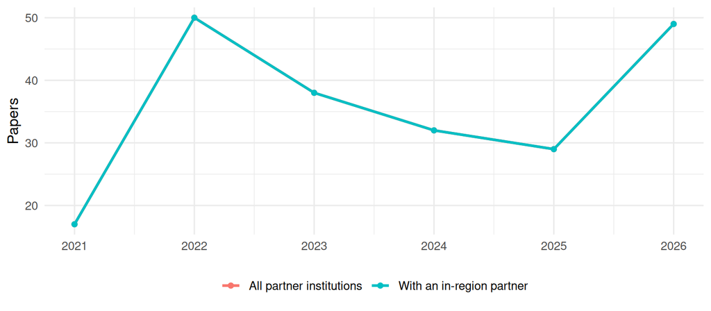

| Partner | Papers in topics |
| --- | --- |
| Iowa State University | 193 |
| University of Iowa | 21 |
| University of Nebraska | 2 |

## Technology base: patents

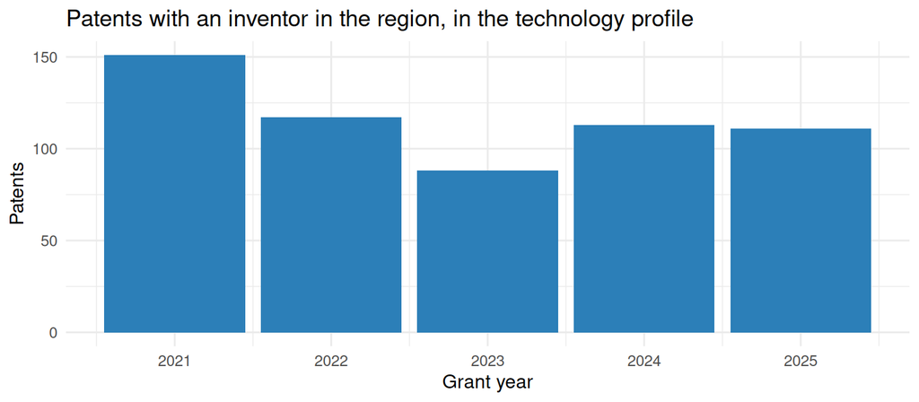

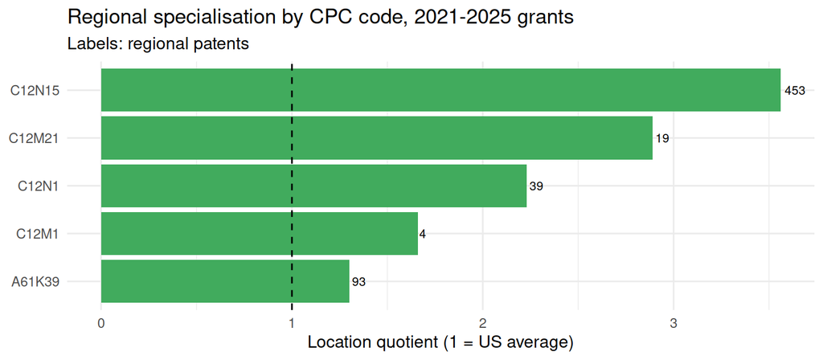

| Assignee | Regional patents in profile |
| --- | --- |
| PIONEER HI-BRED INTERNATIONAL, INC. | 149 |
| M.S. Technologies, L.L.C. | 118 |
| Monsanto Technology LLC | 29 |
| Iowa State University Research Foundation, Inc. | 25 |
| University of Iowa Research Foundation | 23 |
| E.I. DU PONT DE NEMOURS AND COMPANY | 22 |
| INTEGRATED DNA TECHNOLOGIES, INC. | 16 |
| Intervet Inc. | 13 |
| Stine Seed Farm, Inc. | 13 |
| Corteva Agriscience LLC | 12 |

Partner-owned patents invented in the region: 349, of which 50 (14.3%) fall in the Engine’s technology profile.

## Competition

With 580 patents in the technology profile (2021-2025 grants), the Engine’s region would rank **10** among US states; its specialisation (LQ) is 2.844.

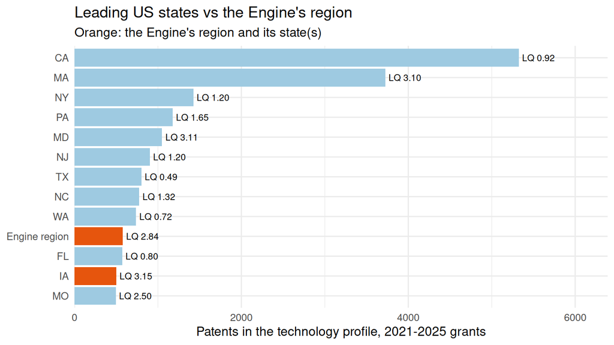

| Country | Share of US patents in profile | Share of world papers in topics |
| --- | --- | --- |
| US | 62.9% | 9.2% |
| CN | 7.0% | 21.6% |
| JP | 6.4% | 2.7% |
| DE | 6.2% | 4.2% |
| GB | 3.8% | 2.9% |
| KR | 3.4% | 2.3% |
| FR | 3.0% | 2.5% |
| CA | 2.9% | 1.6% |
| NL | 2.2% | NA |
| CH | 2.1% | NA |

Patents: inventor countries on US grants in the profile (a patent counts for every country of its inventors). Papers: author countries of OpenAlex works in the Engine’s topics since the window start.

## Data and limitations

- People: PIs and Co-PIs from the NSF Award API; leadership listed on the Engine’s website. Roles come from titles and organisations, revised with OpenAlex evidence.
- Partners: as listed on the Engine’s website, plus organisations of team members. Some Engines publish partner logos without names.
- Region: the Engine’s counties where the list is known (NEO-SMART: 18 Northeast Ohio counties; STELLAR: 11 counties from the NSF abstract), otherwise its states (state-level proxy).
- Technology profile: v3.1 (switch versions in the header). Partner papers and regional patents depend on it: v1 uses mostly CPC subclasses, the v3.1 core uses CPC main groups, which are narrower, so it counts fewer patents and the LQ of a small region rests on few patents.
- Papers: OpenAlex; partner papers are restricted to the Engine’s OpenAlex topics.
- Patents: USPTO grants 2021-2025; inventor locations from PatentsView; pre-grant publications are not included.